# R Bootcamp Problem Set 4

Author

Your name here

Published

November 1, 2026

## Problem Set

Use the data files in the `data/` directory to answer the questions.

For this problem set, you are allowed to help each other, but you are not allowed to post correct answers in slack.

**The problem set is due 12pm on Sept 1.**

## Grading rubric

- Everything is good: full points
- Partially correct answer: depends on how many steps are correct
- Reasonable attempt: half points

## Question 1 **5 points**

1. Load the tidyverse and here packages using `library()`.
2. Import datasets: `data/data_rna_protein.csv.gz` using `read_csv()` and `here()`.

`data_rna_protein.csv.gz`: This is a combined dataset from an RNAseq and SILAC proteomics experiment, where a transcription factor (TF) was differentially expressed and the fold change in RNA and protein calculated between TF-expressing and non-expressing cells.

```r
library(tidyverse)
library(here)
exp_tbl <- read_csv(
  here("data/bootcamp/data_rna_protein.csv.gz")
)
```

## Question 2 **5 points**

Let’s build a data processing workflow step by step. This teaches you how to build complex pipelines gradually - a key skill in data analysis.

**Step 1**: First, explore the data so you know what you’re working with. Use `glimpse()` to see column types and `summary()` to see distributions:

```r
# Always explore your data first!
exp_tbl |> glimpse()
```

```
Rows: 21,282
Columns: 17
$ geneid         <chr> "RFPL1", "DUXA", "RFPL2", "LEUTX", "RFPL3S", "ZSCAN5C",…
$ iDUX4_logFC    <dbl> 9.366333, 8.728522, 8.582827, 8.136148, 8.031894, 7.837…
$ iDUX4_logCPM   <dbl> 8.568344, 9.740241, 9.760915, 8.702694, 5.563714, 6.532…
$ iDUX4_LR       <dbl> 2910.21184, 5195.45733, 4397.04659, 3276.44418, 392.901…
$ iDUX4_pval     <dbl> 0.00e+00, 0.00e+00, 0.00e+00, 0.00e+00, 1.93e-87, 5.12e…
$ iDUX4_fdr      <dbl> 0.00e+00, 0.00e+00, 0.00e+00, 0.00e+00, 8.64e-86, 5.76e…
$ hl.ratio       <dbl> 4.415276, 8.919536, 3.032258, 7.151629, NA, 3.910093, N…
$ area           <dbl> 222742.2, 3523464.3, 119468.9, 1579141.5, NA, 307343.6,…
$ protein.length <dbl> 317, 204, 378, 168, NA, 496, NA, NA, 465, NA, 474, NA, …
$ rep            <dbl> 3.760000, 3.500000, 3.888889, 3.333333, NA, 4.000000, N…
$ IQR            <dbl> 1.952243, 6.435921, 1.694725, 5.303046, NA, 0.000000, N…
$ QCoD           <dbl> 0.4421564, 0.7215533, 0.5588985, 0.7415158, NA, 0.00000…
$ count          <dbl> 25, 32, 9, 6, NA, 1, NA, NA, 21, NA, 10, NA, 1, 80, NA,…
$ mean           <dbl> 0.004465732, -0.003224870, 0.024341945, -0.009047206, N…
$ sd             <dbl> 0.17197783, 0.13994973, 0.29149227, 0.38073424, NA, 2.0…
$ zscore         <dbl> 25.647554, 63.756902, 10.319026, 18.807544, NA, 1.89808…
$ pval           <dbl> 4.500000e-145, 0.000000e+00, 5.780000e-25, 6.550000e-79…
```

```r
exp_tbl |> summary()
```

```
    geneid           iDUX4_logFC       iDUX4_logCPM       iDUX4_LR
 Length:21282       Min.   :-3.4751   Min.   : 1.264   Min.   :    0.000
 Class :character   1st Qu.:-0.9996   1st Qu.: 3.385   1st Qu.:    2.068
 Mode  :character   Median :-0.3772   Median : 4.780   Median :    9.049
                    Mean   :-0.1574   Mean   : 4.801   Mean   :   53.971
                    3rd Qu.: 0.3977   3rd Qu.: 6.064   3rd Qu.:   30.949
                    Max.   : 9.3663   Max.   :14.915   Max.   :13648.327
                    NA's   :8950      NA's   :8950     NA's   :8950
   iDUX4_pval       iDUX4_fdr         hl.ratio             area
 Min.   :0.0000   Min.   :0.0000   Min.   :-19.6540   Min.   :     7952
 1st Qu.:0.0000   1st Qu.:0.0000   1st Qu.: -0.3842   1st Qu.:   290641
 Median :0.0026   Median :0.0052   Median : -0.0529   Median :   545151
 Mean   :0.1341   Mean   :0.1520   Mean   : -0.0306   Mean   :  1112496
 3rd Qu.:0.1504   3rd Qu.:0.2002   3rd Qu.:  0.2283   3rd Qu.:  1014351
 Max.   :0.9976   Max.   :0.9980   Max.   : 19.3091   Max.   :878105037
 NA's   :8950     NA's   :8950     NA's   :15969      NA's   :15969
 protein.length        rep             IQR               QCoD
 Min.   :  19.0   Min.   :3.000   Min.   : 0.0000   Min.   :-7521.713
 1st Qu.: 260.0   1st Qu.:3.333   1st Qu.: 0.3805   1st Qu.:   -2.960
 Median : 433.0   Median :3.495   Median : 0.8014   Median :    0.000
 Mean   : 603.4   Mean   :3.446   Mean   : 1.1079   Mean   :   -1.100
 3rd Qu.: 728.0   3rd Qu.:3.560   3rd Qu.: 1.1911   3rd Qu.:    2.122
 Max.   :8797.0   Max.   :4.000   Max.   :26.1119   Max.   : 3618.200
 NA's   :15969    NA's   :15969   NA's   :15969     NA's   :15969
     count             mean               sd             zscore
 Min.   :   1.0   Min.   :-0.1496   Min.   :0.0152   Min.   :-77.7125
 1st Qu.:   2.0   1st Qu.:-0.0024   1st Qu.:0.1453   1st Qu.: -1.1955
 Median :   8.0   Median : 0.0024   Median :0.3121   Median : -0.1833
 Mean   :  42.1   Mean   : 0.0239   Mean   :0.6794   Mean   :  0.2260
 3rd Qu.:  31.0   3rd Qu.: 0.0315   3rd Qu.:1.3565   3rd Qu.:  0.7153
 Max.   :2646.0   Max.   : 0.3272   Max.   :2.5400   Max.   :105.5495
 NA's   :15969    NA's   :15969     NA's   :15969    NA's   :15969
      pval
 Min.   :0.0000
 1st Qu.:0.0315
 Median :0.3171
 Mean   :0.3816
 3rd Qu.:0.7035
 Max.   :1.0000
 NA's   :15969
```

**Step 2**: Select only the columns we need:

- `geneid` (gene identifier)
- `iDUX4_logFC` (RNA fold change)
- `iDUX4_fdr` (RNA pvalue)
- `hl.ratio` (protein fold change)
- `pval` (protein pvalue)

Use `select()` and list the columns you want to keep:

```r
exp_tbl |>
  select(geneid, iDUX4_logFC, iDUX4_fdr, hl.ratio, pval)
```

```
# A tibble: 21,282 × 5
   geneid   iDUX4_logFC iDUX4_fdr hl.ratio       pval
   <chr>          <dbl>     <dbl>    <dbl>      <dbl>
 1 RFPL1           9.37 0             4.42  4.50e-145
 2 DUXA            8.73 0             8.92  0
 3 RFPL2           8.58 0             3.03  5.78e- 25
 4 LEUTX           8.14 0             7.15  6.55e- 79
 5 RFPL3S          8.03 8.64e- 86    NA    NA
 6 ZSCAN5C         7.84 5.76e-169     3.91  5.77e-  2
 7 USP29           7.71 4.48e- 36    NA    NA
 8 FAM189A2        7.68 1.46e- 41    NA    NA
 9 CCNA1           7.66 0             5.11  7.10e-169
10 ZNF280A         7.55 2.35e- 54    NA    NA
# ℹ 21,272 more rows
```

**Step 3**: Rename columns for clarity (this makes your code more readable).

Use `dplyr::rename()` with the pattern `new_name = old_name, ...`:

```r
exp_tbl |>
  select(geneid, iDUX4_logFC, iDUX4_fdr, hl.ratio, pval) |>
  rename(
    rna_FC = iDUX4_logFC,
    rna_pval = iDUX4_fdr,
    protein_FC = hl.ratio,
    protein_pval = pval
  )
```

```
# A tibble: 21,282 × 5
   geneid   rna_FC  rna_pval protein_FC protein_pval
   <chr>     <dbl>     <dbl>      <dbl>        <dbl>
 1 RFPL1      9.37 0               4.42    4.50e-145
 2 DUXA       8.73 0               8.92    0
 3 RFPL2      8.58 0               3.03    5.78e- 25
 4 LEUTX      8.14 0               7.15    6.55e- 79
 5 RFPL3S     8.03 8.64e- 86      NA      NA
 6 ZSCAN5C    7.84 5.76e-169       3.91    5.77e-  2
 7 USP29      7.71 4.48e- 36      NA      NA
 8 FAM189A2   7.68 1.46e- 41      NA      NA
 9 CCNA1      7.66 0               5.11    7.10e-169
10 ZNF280A    7.55 2.35e- 54      NA      NA
# ℹ 21,272 more rows
```

**Step 4**: Clean the data by removing rows with missing values. Use `drop_na()` to remove rows with any missing values, and `distinct()` to remove duplicate rows:

```r
exp_tbl |>
  select(geneid, iDUX4_logFC, iDUX4_fdr, hl.ratio, pval) |>
  rename(
    rna_FC = iDUX4_logFC,
    rna_pval = iDUX4_fdr,
    protein_FC = hl.ratio,
    protein_pval = pval
  ) |>
  drop_na() |> # Remove rows with any missing values
  distinct() # Remove duplicate rows
```

```
# A tibble: 4,931 × 5
   geneid   rna_FC  rna_pval protein_FC protein_pval
   <chr>     <dbl>     <dbl>      <dbl>        <dbl>
 1 RFPL1      9.37 0               4.42    4.50e-145
 2 DUXA       8.73 0               8.92    0
 3 RFPL2      8.58 0               3.03    5.78e- 25
 4 LEUTX      8.14 0               7.15    6.55e- 79
 5 ZSCAN5C    7.84 5.76e-169       3.91    5.77e-  2
 6 CCNA1      7.66 0               5.11    7.10e-169
 7 PRAMEF1    7.54 0               4.82    3.49e- 76
 8 TPRX1      7.29 2.41e-132       7.35    2.85e-  4
 9 PRAMEF12   7.25 0               7.55    0
10 RFPL4B     7.16 0               7.46    0
# ℹ 4,921 more rows
```

**Step 5**: Finally, arrange the data and save it. Use `arrange()` to sort by RNA fold change (high to low), then protein fold change (low to high):

```r
exp_tbl_subset <- exp_tbl |>
  select(geneid, iDUX4_logFC, iDUX4_fdr, hl.ratio, pval) |>
  rename(
    rna_FC = iDUX4_logFC,
    rna_pval = iDUX4_fdr,
    protein_FC = hl.ratio,
    protein_pval = pval
  ) |>
  drop_na() |>
  distinct() |>
  arrange(desc(rna_FC), protein_FC) # Sort by RNA fold change (high to low), then protein fold change (low to high)

exp_tbl_subset
```

```
# A tibble: 4,931 × 5
   geneid   rna_FC  rna_pval protein_FC protein_pval
   <chr>     <dbl>     <dbl>      <dbl>        <dbl>
 1 RFPL1      9.37 0               4.42    4.50e-145
 2 DUXA       8.73 0               8.92    0
 3 RFPL2      8.58 0               3.03    5.78e- 25
 4 LEUTX      8.14 0               7.15    6.55e- 79
 5 ZSCAN5C    7.84 5.76e-169       3.91    5.77e-  2
 6 CCNA1      7.66 0               5.11    7.10e-169
 7 PRAMEF1    7.54 0               4.82    3.49e- 76
 8 TPRX1      7.29 2.41e-132       7.35    2.85e-  4
 9 PRAMEF12   7.25 0               7.55    0
10 RFPL4B     7.16 0               7.46    0
# ℹ 4,921 more rows
```

## Question 3 **5 points**

Let’s practice good data analysis habits by checking for potential issues. Quality control is essential in real data analysis.

**Check for duplicates and missing values**:

1. Use `count()` to check for duplicate genes
2. Use `summarize()` with `across()` to count missing values in all columns
3. Use summary statistics to understand data distributions

```r
# Check for duplicate genes (there shouldn't be any after distinct())
dup_tbl <-
  exp_tbl_subset |>
  count(geneid) |>
  filter(n > 1) # Any genes appearing more than once?
```

There are 14 duplicate genes in the dataset.

```r
# Summary of missing values by column
exp_tbl_subset |>
  summarize(
    across(everything(), ~ sum(is.na(.)))
  )
```

```
# A tibble: 1 × 5
  geneid rna_FC rna_pval protein_FC protein_pval
   <int>  <int>    <int>      <int>        <int>
1      0      0        0          0            0
```

```r
# Look at the distribution of our main variables
exp_tbl_subset |>
  summarize(
    across(
      c(rna_FC, protein_FC),
      list(
        mean = ~ mean(., na.rm = TRUE),
        median = ~ median(., na.rm = TRUE),
        sd = ~ sd(., na.rm = TRUE)
      )
    ),
    .groups = "drop"
  )
```

```
# A tibble: 1 × 6
  rna_FC_mean rna_FC_median rna_FC_sd protein_FC_mean protein_FC_median
        <dbl>         <dbl>     <dbl>           <dbl>             <dbl>
1      -0.176        -0.309      1.12         -0.0376           -0.0543
# ℹ 1 more variable: protein_FC_sd <dbl>
```

For your reference, here are three different ways to write the same function inside `across()`. They all compute the mean while ignoring `NA` values.

```r
exp_tbl_subset |>
  summarize(
    across(
      c(rna_FC, protein_FC),
      list(
        # Three different ways to write the same function
        mean1 = ~ mean(., na.rm = TRUE),
        mean2 = function(x) mean(, na.rm = TRUE),
        mean3 = \(x) mean(x, na.rm = TRUE),
      )
    )
  )
```

## Question 4 **5 points**

How well do the overall `rna_FC` and `protein_FC` values correlate in this experiment? We’ll explore this with visualization and statistics.

**Step 1**: Create a scatter plot of `rna_FC` vs `protein_FC` using `ggplot()`. Use:

- `aes()` to map x and y variables
- `geom_point()` to create the scatter plot
- `labs()` to add informative axis labels and title

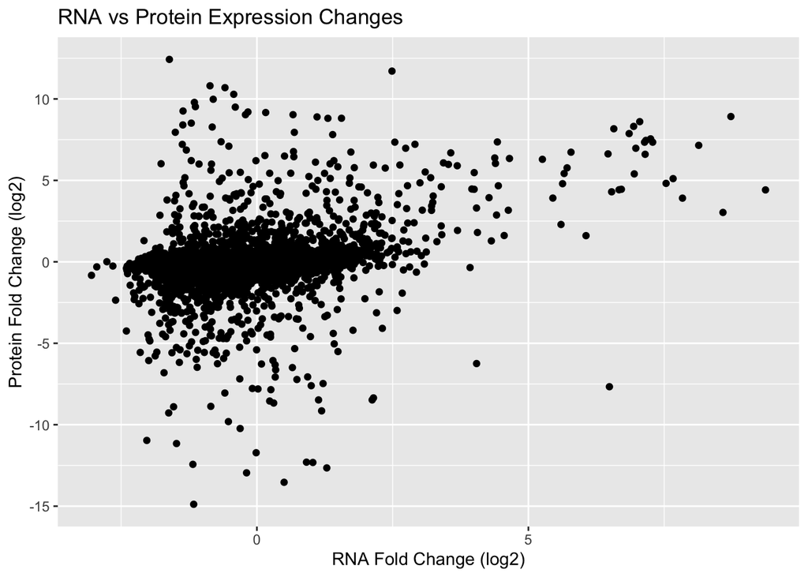

```r
ggplot(
  exp_tbl_subset,
  aes(
    x = rna_FC,
    y = protein_FC
  )
) +
  geom_point() +
  labs(
    x = "RNA Fold Change (log2)",
    y = "Protein Fold Change (log2)",
    title = "RNA vs Protein Expression Changes"
  )
```

**Step 2**: Add reference lines to help interpret the correlation. Use:

- `geom_abline(slope = 1, intercept = 0)` for perfect correlation line
- `geom_smooth(method = "lm", se = FALSE)` for the computed trend line
- adjust the `geom_point()` aesthetic to `alpha = 0.6`, making points slightly transparent for better visualization

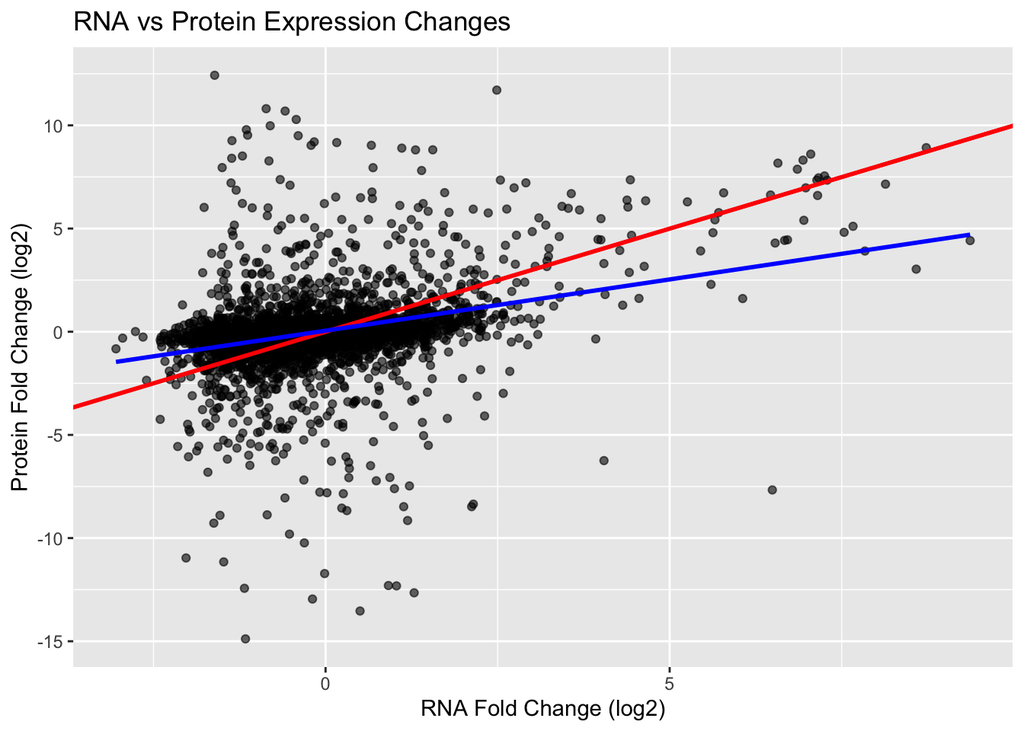

```r
ggplot(
  exp_tbl_subset,
  aes(
    x = rna_FC,
    y = protein_FC
  )
) +
  geom_point(alpha = 0.6) + # Make points a bit transparent
  geom_abline(slope = 1, intercept = 0, color = "red", linewidth = 1) + # Perfect correlation line
  geom_smooth(method = "lm", se = FALSE, color = "blue", linewidth = 1) + # Actual relationship
  labs(
    x = "RNA Fold Change (log2)",
    y = "Protein Fold Change (log2)",
    title = "RNA vs Protein Expression Changes"
  )
```

**Step 3**: Calculate the correlation coefficient using `cor()`. Use Spearman correlation since it’s robust to outliers. Use `?cor` to see the function documentation. You will need to specify two vectors for the calculation, and it’s easiest to provide them using the `$` operator to extract columns from the data frame.

```r
rna_prot_cor <- cor(
  exp_tbl_subset$rna_FC,
  exp_tbl_subset$protein_FC,
  method = "spearman"
)

rna_prot_cor
```

```
[1] 0.3458433
```

## Submit

Be sure to click the “Render” button to render the HTML output.

Then paste the URL of this Posit Cloud project into the problem set on Canvas.